# DRD_2026_Lesson_5

In this lesson we will use preprocessQuantile as normalization method for our data. Let’s recalculate beta values after preprocessQuantile normalization and read the file containing the samplesheet: We will recalculate the preprocessQuantile_results object

```r
rm(list=ls())
setwd("~/Dropbox/DRD_2026/5")
suppressMessages(library(minfi))
load("~/Dropbox/DRD_2026/3/RGset.RData")
preprocessQuantile_results <- preprocessQuantile(RGset)
```

```
## [preprocessQuantile] Mapping to genome.
```

```
## [preprocessQuantile] Fixing outliers.
```

```
## [preprocessQuantile] Quantile normalizing.
```

# CHUNK 1: homoscedasticity and heteroscedasticity

We want to check for homoscedasticity and heteroscedasticity in beta and M values

```r
beta_preprocessQuantile <- getBeta(preprocessQuantile_results)
M_preprocessQuantile <- getM(preprocessQuantile_results)

beta_preprocessQuantile_mean <- apply(beta_preprocessQuantile,1, mean,na.rm=T)
beta_preprocessQuantile_stdev <- apply(beta_preprocessQuantile,1, sd,na.rm=T)

M_preprocessQuantile_mean <- apply(M_preprocessQuantile,1, mean,na.rm=T)
M_preprocessQuantile_stdev <- apply(M_preprocessQuantile,1, sd,na.rm=T)
```

Now we want to plot, for each probe, sd against mean. The plot will contain 485512 dots, they are really a lot. For this reason in this case it is more convenient to use the function smoothScatter() instead of plot(). The lowess function carries out a locally weighted regression of y on x

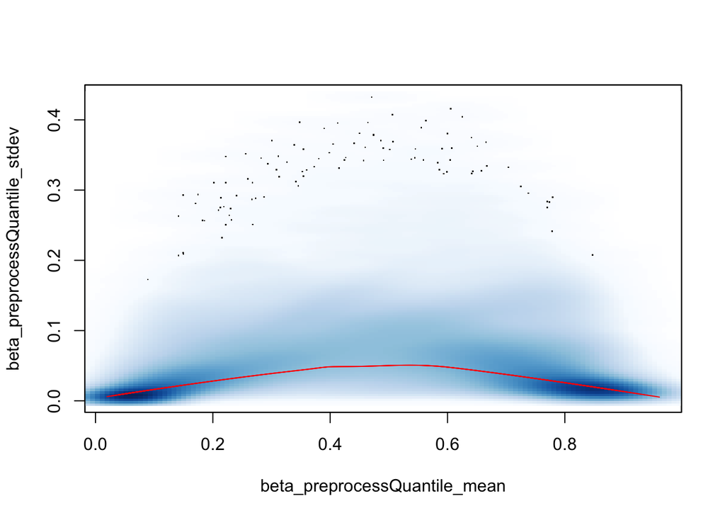

```r
?smoothScatter
smoothScatter(beta_preprocessQuantile_mean, beta_preprocessQuantile_stdev)
?lowess
lines(lowess(beta_preprocessQuantile_mean, beta_preprocessQuantile_stdev), col="red") #lowess carries out a locally weighted regression of y on x
```

```r
pdf("Beta_M_heteoschedasticity_omoscedasticity.pdf")
par(mfrow=c(1,2))
smoothScatter(beta_preprocessQuantile_mean, beta_preprocessQuantile_stdev)
lines(lowess(beta_preprocessQuantile_mean, beta_preprocessQuantile_stdev), col="red") #lowess carries out a locally weighted regression of y on x
smoothScatter(M_preprocessQuantile_mean, M_preprocessQuantile_stdev)
lines(lowess(M_preprocessQuantile_mean, M_preprocessQuantile_stdev), col="red")
dev.off()
```

For this dataset, we do not observe large differences between Beta and M values!

# CHUNK 2: Identification of Differentially methylated positions

We will perform the differential methylation analysis on beta values from data normalized using preprocessQuantile. The analytical steps performed in this tutorial can be applied to any normalization method and to both beta values and M values.

Let’s read the file containing the samplesheet:

```r
pheno <- read.csv("~/Dropbox/DRD_2026/3/Input_data/SampleSheet.csv",header=T, stringsAsFactors=T)
str(pheno)
```

```
## 'data.frame':    8 obs. of  7 variables:
##  $ Sample_ID  : int  21050 21060 22041 22051 21090 21100 23081 23091
##  $ Sample_Well: Factor w/ 8 levels "A11","A12","E11",..: 6 1 4 7 5 2 3 8
##  $ Array      : Factor w/ 8 levels "R01C01","R01C02",..: 2 5 8 4 3 7 1 6
##  $ Slide      : num  9.34e+09 9.34e+09 9.34e+09 9.34e+09 9.38e+09 ...
##  $ Group      : Factor w/ 2 levels "A","B": 1 1 2 2 1 1 2 2
##  $ Gender     : Factor w/ 2 levels "F","M": 1 1 1 1 1 1 1 2
##  $ BMI        : num  21.6 20.8 26.6 26.6 17.5 ...
```

Our aim is to identify the CpG probes that are differentially methyled between samples belonging to groups A and B. We will use a parametric test (t-test) and a non parametric test (Mann-Whitney test). Please note that these statistical appraoches are very basic, and usually researchers adopt much more sophisticated statistical approaches, which allows also to take into account the effect of potential confounding factors. However, in our examples we will keep the things simple, and we will learn how to extract the info in which we are interested in (in this case, the p-value) from the output of a function.

Let’s use the t-test to compare the first CpG of beta_preprocessQuantile between groups A and B:

```r
? t.test
t_test <- t.test(beta_preprocessQuantile[1,] ~ pheno$Group)
t_test
```

```
##
##  Welch Two Sample t-test
##
## data:  beta_preprocessQuantile[1, ] by pheno$Group
## t = 0.44666, df = 3.7029, p-value = 0.68
## alternative hypothesis: true difference in means between group A and group B is not equal to 0
## 95 percent confidence interval:
##  -0.06905351  0.09454516
## sample estimates:
## mean in group A mean in group B
##       0.7654342       0.7526884
```

Let’s use the Mann-Whitney test to compare the first CpG of beta_preprocessQuantile between groups A and B:

```r
wilcox <- wilcox.test(beta_preprocessQuantile[1,]~ pheno$Group)
wilcox
```

```
##
##  Wilcoxon rank sum exact test
##
## data:  beta_preprocessQuantile[1, ] by pheno$Group
## W = 9, p-value = 0.8857
## alternative hypothesis: true location shift is not equal to 0
```

Note that both the t.test and the wicox.test functions return a list:

```r
str(t_test)
```

```
## List of 10
##  $ statistic  : Named num 0.447
##   ..- attr(*, "names")= chr "t"
##  $ parameter  : Named num 3.7
##   ..- attr(*, "names")= chr "df"
##  $ p.value    : num 0.68
##  $ conf.int   : num [1:2] -0.0691 0.0945
##   ..- attr(*, "conf.level")= num 0.95
##  $ estimate   : Named num [1:2] 0.765 0.753
##   ..- attr(*, "names")= chr [1:2] "mean in group A" "mean in group B"
##  $ null.value : Named num 0
##   ..- attr(*, "names")= chr "difference in means between group A and group B"
##  $ stderr     : num 0.0285
##  $ alternative: chr "two.sided"
##  $ method     : chr "Welch Two Sample t-test"
##  $ data.name  : chr "beta_preprocessQuantile[1, ] by pheno$Group"
##  - attr(*, "class")= chr "htest"
```

```r
str(wilcox)
```

```
## List of 7
##  $ statistic  : Named num 9
##   ..- attr(*, "names")= chr "W"
##  $ parameter  : NULL
##  $ p.value    : num 0.886
##  $ null.value : Named num 0
##   ..- attr(*, "names")= chr "location shift"
##  $ alternative: chr "two.sided"
##  $ method     : chr "Wilcoxon rank sum exact test"
##  $ data.name  : chr "beta_preprocessQuantile[1, ] by pheno$Group"
##  - attr(*, "class")= chr "htest"
```

We are interested in the “p.value” element of these lists.

```r
t_test$p.value
```

```
## [1] 0.6799849
```

```r
wilcox$p.value
```

```
## [1] 0.8857143
```

For 1 row (1 CpG probe) it is easy, but…how can I apply the 2 tests to each row of the dataframe (that is, to each probe of the microarray) and extract the p-value? We will use the apply() function, that we have already met in Lesson 4 to calculate the mean of each row of the matrix. However, unlike the mean() function, t.test() and wilcox.test() functions do not return a value, but a list; therefore, we have to create an ad hoc function:

```r
My_ttest_function <- function(x) {
  t_test <- t.test(x~ pheno$Group)
  return(t_test$p.value)
}
```

Let’s apply the function to few rows of beta_preprocessQuantile

```r
firstbeta_preprocessQuantile <- beta_preprocessQuantile[1:10,]
pValues_ttest <- apply(firstbeta_preprocessQuantile,1, My_ttest_function)
pValues_ttest
```

```
## cg13869341 cg14008030 cg12045430 cg20826792 cg00381604 cg20253340 cg21870274
## 0.67998491 0.52253961 0.48786355 0.04189629 0.26590952 0.38041135 0.12745604
## cg03130891 cg24335620 cg16162899
## 0.64948694 0.26401633 0.37096580
```

Great, everything works fine!

Let’s do the same with the non-parametric test

```r
My_mannwhitney_function <- function(x) {
  wilcox <- wilcox.test(x~ pheno$Group)
  return(wilcox$p.value)
}
pValues_wilcox <- apply(firstbeta_preprocessQuantile,1, My_mannwhitney_function)
pValues_wilcox
```

```
## cg13869341 cg14008030 cg12045430 cg20826792 cg00381604 cg20253340 cg21870274
## 0.88571429 0.68571429 0.68571429 0.11428571 0.02857143 0.48571429 0.11428571
## cg03130891 cg24335620 cg16162899
## 0.68571429 0.68571429 0.48571429
```

You can apply your brand new functions to all the rows of the beta_preprocessQuantile matrix. As this step can take several minutes, in this turial we will apply the parametric and non parametric functions only to the first 20000 probes

```r
first20k_beta_preprocessQuantile <- beta_preprocessQuantile[1:20000,]
pValues_ttest_first20k <- apply(first20k_beta_preprocessQuantile,1, My_ttest_function)
length(pValues_ttest_first20k)
```

```
## [1] 20000
```

```r
pValues_wilcox_first20k <- apply(first20k_beta_preprocessQuantile,1, My_mannwhitney_function)
length(pValues_wilcox_first20k)
```

```
## [1] 20000
```

We can create a data.frame with all the beta values and the pValue column

```r
final_ttest_first20k <- data.frame(first20k_beta_preprocessQuantile, pValues_ttest_first20k)
head(final_ttest_first20k)
```

```
##            X9344737127_R01C02 X9344737127_R03C02 X9344737127_R06C01
## cg13869341         0.73914779         0.76950459          0.6995062
## cg14008030         0.69185593         0.64592974          0.6885158
## cg12045430         0.13474718         0.11699326          0.1004484
## cg20826792         0.17078769         0.28879485          0.2947075
## cg00381604         0.05846309         0.09592991          0.1045477
## cg20253340         0.42958351         0.51681548          0.4396129
##            X9344737127_R02C02 X9376538140_R02C01 X9376538140_R05C01
## cg13869341          0.7184184         0.78299289         0.77009158
## cg14008030          0.6031361         0.63207688         0.56279678
## cg12045430          0.1218535         0.14349114         0.12472814
## cg20826792          0.2819566         0.22464011         0.20651747
## cg00381604          0.1000693         0.09964109         0.08688974
## cg20253340          0.4760213         0.46439970         0.37458736
##            X9376538140_R01C01 X9376538140_R04C01 pValues_ttest_first20k
## cg13869341          0.7751171          0.8177119             0.67998491
## cg14008030          0.6861439          0.6460894             0.52253961
## cg12045430          0.4254814          0.1188433             0.48786355
## cg20826792          0.3439327          0.2847663             0.04189629
## cg00381604          0.3128018          0.1086204             0.26590952
## cg20253340          0.4502786          0.6004477             0.38041135
```

```r
dim(final_ttest_first20k)
```

```
## [1] 20000     9
```

```r
final_wilcox_first20k <- data.frame(first20k_beta_preprocessQuantile, pValues_wilcox_first20k)
head(final_wilcox_first20k)
```

```
##            X9344737127_R01C02 X9344737127_R03C02 X9344737127_R06C01
## cg13869341         0.73914779         0.76950459          0.6995062
## cg14008030         0.69185593         0.64592974          0.6885158
## cg12045430         0.13474718         0.11699326          0.1004484
## cg20826792         0.17078769         0.28879485          0.2947075
## cg00381604         0.05846309         0.09592991          0.1045477
## cg20253340         0.42958351         0.51681548          0.4396129
##            X9344737127_R02C02 X9376538140_R02C01 X9376538140_R05C01
## cg13869341          0.7184184         0.78299289         0.77009158
## cg14008030          0.6031361         0.63207688         0.56279678
## cg12045430          0.1218535         0.14349114         0.12472814
## cg20826792          0.2819566         0.22464011         0.20651747
## cg00381604          0.1000693         0.09964109         0.08688974
## cg20253340          0.4760213         0.46439970         0.37458736
##            X9376538140_R01C01 X9376538140_R04C01 pValues_wilcox_first20k
## cg13869341          0.7751171          0.8177119              0.88571429
## cg14008030          0.6861439          0.6460894              0.68571429
## cg12045430          0.4254814          0.1188433              0.68571429
## cg20826792          0.3439327          0.2847663              0.11428571
## cg00381604          0.3128018          0.1086204              0.02857143
## cg20253340          0.4502786          0.6004477              0.48571429
```

```r
dim(final_wilcox_first20k)
```

```
## [1] 20000     9
```

We can order the probes on the basis of the pValues column (from the smallest to the largest value)

```r
final_ttest_first20k <- final_ttest_first20k[order(final_ttest_first20k$pValues_ttest_first20k),]
head(final_ttest_first20k)
```

```
##            X9344737127_R01C02 X9344737127_R03C02 X9344737127_R06C01
## cg00147160         0.40907489         0.40395268         0.34677567
## cg14914422         0.32145688         0.30750562         0.24472666
## cg09473867         0.04168016         0.04317311         0.05235453
## cg25978218         0.20257688         0.25247419         0.45067145
## cg18154117         0.64307543         0.58601626         0.36963643
## cg11799650         0.20758273         0.22121794         0.34532280
##            X9344737127_R02C02 X9376538140_R02C01 X9376538140_R05C01
## cg00147160         0.36517947         0.42370284          0.4131399
## cg14914422         0.25437815         0.30339207          0.3290041
## cg09473867         0.05255956         0.04322238          0.0433248
## cg25978218         0.42926544         0.17350541          0.1796035
## cg18154117         0.36635971         0.57234962          0.6567593
## cg11799650         0.29937972         0.19707495          0.1733119
##            X9376538140_R01C01 X9376538140_R04C01 pValues_ttest_first20k
## cg00147160         0.34446583         0.34958276           7.371467e-05
## cg14914422         0.23800262         0.23057053           9.750103e-05
## cg09473867         0.05566484         0.05299677           1.349507e-04
## cg25978218         0.38048423         0.37558371           1.977524e-04
## cg18154117         0.42184015         0.43663288           2.490115e-04
## cg11799650         0.32566641         0.29110664           4.283231e-04
```

```r
final_wilcox_first20k <- final_wilcox_first20k[order(final_wilcox_first20k$pValues_wilcox_first20k),]
head(final_wilcox_first20k) #Note that in these settings the pvalues from Mann-Whitney tests are discrete
```

```
##            X9344737127_R01C02 X9344737127_R03C02 X9344737127_R06C01
## cg00381604         0.05846309         0.09592991          0.1045477
## cg17149495         0.72517404         0.73466157          0.7742136
## cg18024856         0.12749133         0.07603291          0.1354115
## cg08939496         0.79736900         0.77656754          0.6795802
## cg05662829         0.72568997         0.71536574          0.6859303
## cg08258224         0.70397508         0.68573484          0.8200589
##            X9344737127_R02C02 X9376538140_R02C01 X9376538140_R05C01
## cg00381604          0.1000693         0.09964109         0.08688974
## cg17149495          0.7457946         0.69211431         0.74052050
## cg18024856          0.1640822         0.09915869         0.11421504
## cg08939496          0.7183194         0.83588818         0.82138202
## cg05662829          0.6726331         0.81876726         0.74025011
## cg08258224          0.7226379         0.36607173         0.71147781
##            X9376538140_R01C01 X9376538140_R04C01 pValues_wilcox_first20k
## cg00381604          0.3128018          0.1086204              0.02857143
## cg17149495          0.7629406          0.7606389              0.02857143
## cg18024856          0.1523937          0.1553234              0.02857143
## cg08939496          0.7367617          0.7537639              0.02857143
## cg05662829          0.6493831          0.7063788              0.02857143
## cg08258224          0.7324056          0.7703751              0.02857143
```

How many probes have a pValue<=0.05?

```r
final_ttest_first20k_0.05 <- final_ttest_first20k[final_ttest_first20k$pValues_ttest_first20k<=0.05,]
dim(final_ttest_first20k_0.05)
```

```
## [1] 1438    9
```

```r
final_wilcox_first20k_0.05 <- final_wilcox_first20k[final_wilcox_first20k$pValues_wilcox_first20k<=0.05,]
dim(final_wilcox_first20k_0.05)
```

```
## [1] 1181    9
```

```r
intersection <- intersect(rownames(final_ttest_first20k_0.05),rownames(final_wilcox_first20k_0.05))
length(intersection)
```

```
## [1] 827
```

# CHUNK 3: dmpFinder

```r
?dmpFinder
```

As you can see, dmpFinder is based on limma

```r
pValues_dmpFinder_first20k <- dmpFinder(first20k_beta_preprocessQuantile,pheno=pheno$Group,type="categorical")
length(pValues_dmpFinder_first20k)
```

```
## [1] 4
```

```r
head(pValues_dmpFinder_first20k)
```

```
##             intercept         f         pval      qval
## cg09473867 0.04285011 149.41918 1.824650e-05 0.2382118
## cg24254842 0.15665602 113.84081 3.997762e-05 0.2609579
## cg00147160 0.41246759  94.23881 6.857942e-05 0.2722893
## cg14914422 0.31533967  87.94943 8.342705e-05 0.2722893
## cg01399319 0.88251887  76.23728 1.248398e-04 0.2880072
## cg19247124 0.13458138  73.68354 1.373597e-04 0.2880072
```

```r
table(rownames(final_ttest_first20k)==rownames(pValues_dmpFinder_first20k))
```

```
##
## FALSE  TRUE
## 19836   164
```

We will use the merge() function to merge the final_ttest_first20k with the pValues_dmpFinder_first20k dataframe

```r
final_dmpFinder_first20k <- merge(first20k_beta_preprocessQuantile,pValues_dmpFinder_first20k,by="row.names")
head(final_dmpFinder_first20k)
```

```
##    Row.names 9344737127_R01C02 9344737127_R03C02 9344737127_R06C01
## 1 cg00000957        0.81640937        0.82114722         0.8155907
## 2 cg00001446        0.82185854        0.80003893         0.7962052
## 3 cg00001534        0.90610172        0.91086961         0.9029241
## 4 cg00002028        0.06068736        0.06908112         0.0640245
## 5 cg00002593        0.77573976        0.83001325         0.8208749
## 6 cg00002837        0.43292499        0.36323490         0.3855876
##   9344737127_R02C02 9376538140_R02C01 9376538140_R05C01 9376538140_R01C01
## 1        0.81361638         0.8119120        0.82062518        0.81896818
## 2        0.80602512         0.8489746        0.83697850        0.79149513
## 3        0.88071301         0.9082726        0.90604794        0.89457867
## 4        0.08284857         0.1015421        0.07787474        0.08182502
## 5        0.81381464         0.7930347        0.80870725        0.80847452
## 6        0.42348142         0.4284411        0.38012955        0.41017220
##   9376538140_R04C01  intercept           f       pval      qval
## 1        0.82091943 0.81752343 0.008519631 0.92946294 0.6373615
## 2        0.81782946 0.82696263 3.989291107 0.09277006 0.3672238
## 3        0.90503726 0.90782297 4.545336550 0.07699854 0.3579074
## 4        0.07764969 0.07729634 0.005218851 0.94475758 0.6408768
## 5        0.81764123 0.80187374 1.265015352 0.30367555 0.4491793
## 6        0.41277305 0.40118263 0.126789954 0.73396941 0.5852405
```

```r
rownames(final_dmpFinder_first20k) <- final_dmpFinder_first20k[,1]
head(final_dmpFinder_first20k)
```

```
##             Row.names 9344737127_R01C02 9344737127_R03C02 9344737127_R06C01
## cg00000957 cg00000957        0.81640937        0.82114722         0.8155907
## cg00001446 cg00001446        0.82185854        0.80003893         0.7962052
## cg00001534 cg00001534        0.90610172        0.91086961         0.9029241
## cg00002028 cg00002028        0.06068736        0.06908112         0.0640245
## cg00002593 cg00002593        0.77573976        0.83001325         0.8208749
## cg00002837 cg00002837        0.43292499        0.36323490         0.3855876
##            9344737127_R02C02 9376538140_R02C01 9376538140_R05C01
## cg00000957        0.81361638         0.8119120        0.82062518
## cg00001446        0.80602512         0.8489746        0.83697850
## cg00001534        0.88071301         0.9082726        0.90604794
## cg00002028        0.08284857         0.1015421        0.07787474
## cg00002593        0.81381464         0.7930347        0.80870725
## cg00002837        0.42348142         0.4284411        0.38012955
##            9376538140_R01C01 9376538140_R04C01  intercept           f
## cg00000957        0.81896818        0.82091943 0.81752343 0.008519631
## cg00001446        0.79149513        0.81782946 0.82696263 3.989291107
## cg00001534        0.89457867        0.90503726 0.90782297 4.545336550
## cg00002028        0.08182502        0.07764969 0.07729634 0.005218851
## cg00002593        0.80847452        0.81764123 0.80187374 1.265015352
## cg00002837        0.41017220        0.41277305 0.40118263 0.126789954
##                  pval      qval
## cg00000957 0.92946294 0.6373615
## cg00001446 0.09277006 0.3672238
## cg00001534 0.07699854 0.3579074
## cg00002028 0.94475758 0.6408768
## cg00002593 0.30367555 0.4491793
## cg00002837 0.73396941 0.5852405
```

```r
final_dmpFinder_first20k <- final_dmpFinder_first20k[order(final_dmpFinder_first20k$pval),]
head(final_dmpFinder_first20k)
```

```
##             Row.names 9344737127_R01C02 9344737127_R03C02 9344737127_R06C01
## cg09473867 cg09473867        0.04168016        0.04317311        0.05235453
## cg24254842 cg24254842        0.15872861        0.15952195        0.28559818
## cg00147160 cg00147160        0.40907489        0.40395268        0.34677567
## cg14914422 cg14914422        0.32145688        0.30750562        0.24472666
## cg01399319 cg01399319        0.88334874        0.87516261        0.85595999
## cg19247124 cg19247124        0.14159854        0.11948331        0.06122449
##            9344737127_R02C02 9376538140_R02C01 9376538140_R05C01
## cg09473867        0.05255956        0.04322238         0.0433248
## cg24254842        0.28507633        0.14961596         0.1587576
## cg00147160        0.36517947        0.42370284         0.4131399
## cg14914422        0.25437815        0.30339207         0.3290041
## cg01399319        0.86013584        0.88462509         0.8869391
## cg19247124        0.06275233        0.15164837         0.1255953
##            9376538140_R01C01 9376538140_R04C01  intercept         f
## cg09473867        0.05566484        0.05299677 0.04285011 149.41918
## cg24254842        0.26475540        0.24213309 0.15665602 113.84081
## cg00147160        0.34446583        0.34958276 0.41246759  94.23881
## cg14914422        0.23800262        0.23057053 0.31533967  87.94943
## cg01399319        0.85879701        0.85423465 0.88251887  76.23728
## cg19247124        0.05856086        0.07477696 0.13458138  73.68354
##                    pval      qval
## cg09473867 1.824650e-05 0.2382118
## cg24254842 3.997762e-05 0.2609579
## cg00147160 6.857942e-05 0.2722893
## cg14914422 8.342705e-05 0.2722893
## cg01399319 1.248398e-04 0.2880072
## cg19247124 1.373597e-04 0.2880072
```

How many probes have a pValue<=0.05?

```r
final_dmpFinder_first20k_0.05 <- final_dmpFinder_first20k[final_dmpFinder_first20k$pval<=0.05,]
dim(final_dmpFinder_first20k_0.05)
```

```
## [1] 1844   13
```

Lest’s visualize the intersection between the 3 approaches that we used; we will prepare a Venn Diagram using the VennDiagram function

```r
#install.packages("VennDiagram")
library(VennDiagram)
?venn.diagram
venn.diagram(list(A=rownames(final_dmpFinder_first20k_0.05),B=rownames(final_ttest_first20k_0.05),C=rownames(final_wilcox_first20k_0.05)),filename = "Venn_differentially_methylated_positions.png")
```

```
## [1] 1
```

# CHUNK 4: analysis of a large dataset

Now let’s try to perform parametric and non parametric tests on a larger dataset (chr18_large_example.RData). I have already prepared an R object containing chr18 beta values for 64 subjects, 32 normal and 32 with cancer. The pheno vector is:

```r
pheno_large <- factor(c(rep("normal",32),rep("cancer",32)))
pheno_large
```

```
##  [1] normal normal normal normal normal normal normal normal normal normal
## [11] normal normal normal normal normal normal normal normal normal normal
## [21] normal normal normal normal normal normal normal normal normal normal
## [31] normal normal cancer cancer cancer cancer cancer cancer cancer cancer
## [41] cancer cancer cancer cancer cancer cancer cancer cancer cancer cancer
## [51] cancer cancer cancer cancer cancer cancer cancer cancer cancer cancer
## [61] cancer cancer cancer cancer
## Levels: cancer normal
```

```r
load("~/Dropbox/DRD_2026/5/chr18_large_example.RData")
ls()
```

```
##  [1] "beta_preprocessQuantile"          "beta_preprocessQuantile_mean"
##  [3] "beta_preprocessQuantile_stdev"    "chr18_large_example"
##  [5] "final_dmpFinder_first20k"         "final_dmpFinder_first20k_0.05"
##  [7] "final_ttest_first20k"             "final_ttest_first20k_0.05"
##  [9] "final_wilcox_first20k"            "final_wilcox_first20k_0.05"
## [11] "first20k_beta_preprocessQuantile" "firstbeta_preprocessQuantile"
## [13] "intersection"                     "M_preprocessQuantile"
## [15] "M_preprocessQuantile_mean"        "M_preprocessQuantile_stdev"
## [17] "My_mannwhitney_function"          "My_ttest_function"
## [19] "pheno"                            "pheno_large"
## [21] "preprocessQuantile_results"       "pValues_dmpFinder_first20k"
## [23] "pValues_ttest"                    "pValues_ttest_first20k"
## [25] "pValues_wilcox"                   "pValues_wilcox_first20k"
## [27] "RGset"                            "t_test"
## [29] "wilcox"
```

```r
head(chr18_large_example)
```

```
##              Subject_1   Subject_2    Subject_3   Subject_4   Subject_5
## cg00002236 0.051924210 0.039619170 0.0637307800 0.048701550 0.043449720
## cg00005215 0.918009400 0.913728000 0.8796654000 0.904910800 0.817326000
## cg00008713 0.079664810 0.078984420 0.1272162000 0.077300300 0.080132220
## cg00009970 0.012037380 0.028638370 0.0259769700 0.027369580 0.014679520
## cg00012238 0.227600200 0.250835100 0.4569388000 0.292086000 0.255555700
## cg00014996 0.002975828 0.005993401 0.0001673069 0.004635822 0.003584911
##             Subject_6   Subject_7   Subject_8   Subject_9 Subject_10 Subject_11
## cg00002236 0.03030228 0.037410770 0.034971830 0.025557060 0.03552555 0.03621641
## cg00005215 0.87756100 0.900757600 0.893627000 0.905713000 0.91559640 0.93575960
## cg00008713 0.06193672 0.065214460 0.063196320 0.052319070 0.06272060 0.06442876
## cg00009970 0.01828937 0.029580250 0.010760880 0.018628200 0.01705869 0.01616332
## cg00012238 0.28803490 0.243381600 0.265967400 0.389922300 0.26373380 0.42958300
## cg00014996 0.00001000 0.003213845 0.001348037 0.003494899 0.00001000 0.01117144
##              Subject_12  Subject_13 Subject_14 Subject_15  Subject_16
## cg00002236 0.0322707700 0.028632920 0.03662413 0.03488821 0.032454840
## cg00005215 0.9422333000 0.934184200 0.90361530 0.84092860 0.900810000
## cg00008713 0.0517122300 0.056819270 0.05754937 0.05339904 0.062249670
## cg00009970 0.0000100000 0.009129659 0.01381849 0.02276441 0.003073726
## cg00012238 0.2527888000 0.285876700 0.33909950 0.28959050 0.264794200
## cg00014996 0.0002651671 0.001601406 0.00001000 0.00001000 0.000010000
##             Subject_17  Subject_18  Subject_19  Subject_20  Subject_21
## cg00002236 0.034979200 0.042156240 0.036207260 0.045472950 0.030814280
## cg00005215 0.895639600 0.896318100 0.833297200 0.858381900 0.830982300
## cg00008713 0.060076410 0.068092610 0.062181280 0.070341220 0.048015460
## cg00009970 0.010532600 0.009991204 0.018443180 0.009958929 0.007008213
## cg00012238 0.253625700 0.336847100 0.262692400 0.237629300 0.292530300
## cg00014996 0.001980767 0.000010000 0.004870268 0.005224958 0.002624116
##             Subject_22  Subject_23  Subject_24  Subject_25 Subject_26
## cg00002236 0.041679950 0.032258160 0.045818560 0.038748400 0.03135229
## cg00005215 0.871341800 0.891431300 0.869692300 0.863139300 0.93137040
## cg00008713 0.061713180 0.053883100 0.066658930 0.053977770 0.05735427
## cg00009970 0.014470510 0.015085770 0.007678816 0.015429800 0.01373107
## cg00012238 0.398408000 0.269042600 0.285924200 0.274741200 0.25528740
## cg00014996 0.003057802 0.003585184 0.004300429 0.003861612 0.00001000
##             Subject_27  Subject_28 Subject_29  Subject_30  Subject_31
## cg00002236 0.035467290 0.039747520 0.04137253 0.039519660 0.043037190
## cg00005215 0.813336300 0.909070400 0.91627980 0.871833800 0.879089700
## cg00008713 0.060094160 0.057323430 0.06359669 0.089519930 0.060377450
## cg00009970 0.020371340 0.013279540 0.01089359 0.013727520 0.028805400
```

[output cut: 36 more lines]

```
## cg00014996 0.001156038 0.00001000 0.00001000 0.0003517051 0.009857366
##             Subject_59  Subject_60  Subject_61  Subject_62 Subject_63
## cg00002236 0.031536300 0.049171310 0.046699040 0.044465670 0.04517000
## cg00005215 0.867225500 0.927497800 0.921970600 0.886995500 0.89501710
## cg00008713 0.056424860 0.057986950 0.060974510 0.072856330 0.06139426
## cg00009970 0.014459640 0.019488790 0.014169150 0.012118910 0.01941472
## cg00012238 0.368183800 0.316199600 0.340919100 0.270603100 0.31449200
## cg00014996 0.003455899 0.003903026 0.003366298 0.003259631 0.00001000
##             Subject_64
## cg00002236 0.031395640
## cg00005215 0.925778900
## cg00008713 0.059795820
## cg00009970 0.017467720
## cg00012238 0.296342500
## cg00014996 0.006306296
```

Build a function to perform ttest and a function to perform Mann-Whitney test